# Analysis of the Effect of State-Level Policies on Vehicle Traffic Fatalities

Blake, Charlie, Eshna, Noah, Group 7

February 12, 2021

# 1 Abstract

From 2019 to 2020, the US saw a drastic increase in traffic deaths, with an estimate of 1,800 additional traffic deaths (Schwartz, 2020). This report analyzes data collected by The National Highway Traffic Safety Administration from 1982 to 1988 to explore any influential variables that could potentially be used in future policy-making to reduce the number of traffic fatalities. The relationships among all available variables were analyzed, and a fixed-effects longitudinal model was fitted containing the most relevant and important variables from the data set. Model diagnostics and sensitivity analysis were performed to assess the validity of the model’s assumptions. The one policy that appears to have a reducing effect on traffic fatalities is the beer tax, which was significant in the model. Mandatory jail time for a DUI has a significant p-value but unexpectedly has an increasing effect on fatalities. Causal interpretation is not strongly supported, as there is the potential for many omitted variables that could cause bias in the results reported here.

# 2 Introduction

With improvements in safety technology and policy, the fatality rate per 100 million vehicle miles driven has decreased from 25 in 1921 to just 2 in 2015 (Holodny, 2015). Although these improvements had a significant effect on fatalities, recently that has not been the case. The engineering firm Sam Schwarz (2020) found a 12.7% increase in the fatalities per vehicle miles traveled from the first six months of 2019 to the first six months of 2020. Not only are improvements in public policy important to the preservation of human life, but motor vehicle crashes also significantly affect the economy. In 2010, the economic costs associated with motor vehicle crashes were estimated to be $242 billion (Blincoe et al., 2015). With an ever-changing transportation grid, it’s critical to find what new implementations of policy can reduce the amount of traffic fatalities.

# 3 Background

The data set utilized in this study is from the US Department of Transportation Fatal Accident Reporting System. It is available through the R package “AER” which stands for applied econometrics with R. The data set contains information on automobile fatalities from each US state, excluding Hawaii and Alaska, from 1982 to 1988. There are a total of 336 observations, which include 7 annual observations for each of the 48 states. Percentages of each state’s Mormon and Baptist population are given. Economic figures such as income per capita, employment per population, and the US unemployment rate and the US employment per population ratio are also listed. The amount of spirits consumed as well as each state’s beer tax is given. Information on whether a state has a preliminary breath test law, mandatory jail sentence, and mandatory community service for a DUI. The number of vehicle fatalities for 15-17, 18-20, and 21-24 year old drivers is given, as well as their night time vehicle fatalities and total populations. The total number of alcohol involved vehicle fatalities is listed. Each state contains information on its total population. The average miles per driver is given. Each state’s legal drinking age and the percentage of residents in dry counties is listed.

A previous study by Wagenaar, Livingston, and Staras (2015) found that a beer tax increase in the state of Illinois decreased average monthly fatal alcohol-related crashes by 26 percent. This was done by examining the monthly crash data 104 months before the tax increase and 28 months after. Additionally, a meta-analysis by Wagenaar, Salois, and Komro (2009) found that public policies that raise prices of alcohol are an effective means to reduce drinking.

# 4 Descriptive Analysis

In the table below, one can see that a few states in the early 80s made policy changes to mandatory community survive, mandatory jail sentence, and preliminary breath test laws for drinking while intoxicated. Additionally, the average minimum drinking age for each state went from about 20 to 21 from 1982 to 1988.

|  | 1982 (N = 48) | 1983 (N = 48) | 1984 (N = 48) | 1985 (N = 48) | 1986 (N = 48) | 1987 (N = 48) | 1988 (N = 48) |
| --- | --- | --- | --- | --- | --- | --- | --- |
| **Drinking Age** |  |  |  |  |  |  |  |
| Mean | 20.03 | 20.1 | 20.18 | 20.36 | 20.62 | 20.92 | 20.97 |
| **Mandatory Community Service** |  |  |  |  |  |  |  |
| Count | 5 | 8 | 9 | 10 | 10 | 10 | 10 |
| **Mandatory Jail Sentence** |  |  |  |  |  |  |  |
| Count | 9 | 13 | 14 | 15 | 15 | 14 | 14 |
| **Preliminary Breath Test Law** |  |  |  |  |  |  |  |
| Count | 18 | 22 | 22 | 22 | 23 | 24 | 24 |

The figure below describes the US unemployment rate across the years included in this study.

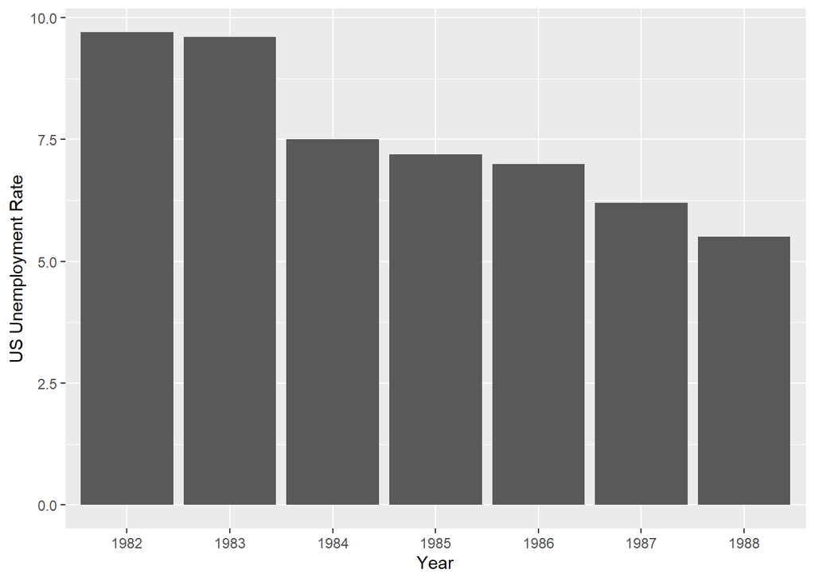

Figure 4.1: US unemployment rate by year.

The figure below describes the US employment population rate ratio across the years included in this study.

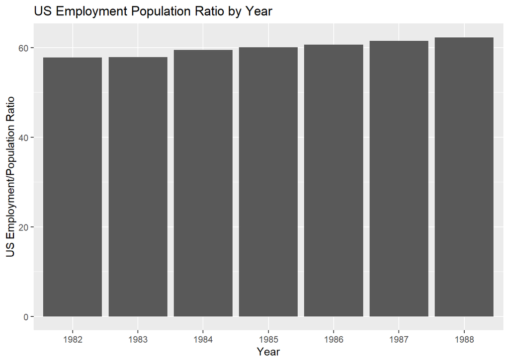

Figure 4.2: US employment population ratio by year.

The two figures above show some improvements in the economy from 1982 to 1988. The US Unemployment rate decreases significantly in this time frame, and the US Employment Population Ratio increases each year.

# 5 Statistical Approach

There are three main linear regression methods for analyzing longitudinal data: 1) fixed effects (FE), 2) random effects (RE), and 3) pooled ordinary least squares (OLS) (Dougherty, 2007). The third may only be used if the control variables are exhaustively comprehesive so that they capture all of the relevant variation between the entities (states), which is certainly not the case here (Dougherty, 2007). The second (RE) may be used when the observations in the data consist of a random sample from a larger population; since the entities in this case are not randomly selected states this rules out using RE regression (Dougherty, 2007). The first (FE) is highly attractive in that it allows for the elimination of unobserved, time-invariant heterogeneity between entities that might induce bias in the regression (Dougherty, 2007). There are three versions of FE linear regression, they are 1) within-groups, 2) first differences, and 3) least squares dummy variable (LSDV) (Dougherty, 2007). This analysis uses the third option, which is technically equivalent to the first, due to ease of implementation and interpretation of results in R. The standard specification of a linear longitudinal model is given by Dougherty (2007):

$Y_{it} = \beta_1 + \sum^{k}_{j=2}\beta_jX_{jit}+ \sum^{s}_{p=1}\gamma_pZ_{pi} + \delta t + \epsilon_{it}$

where “Y is the dependent variable, $X_{j}$ are observed explanatory variables, and the $Z_{p}$ are unobserved explanatory variables” (Dougherty, 2007). The index $i$ indicates the entity, $t$ indicates the time period, $j$ and $p$ indicate different explanatory variables, $\delta t$ is a trend term to allow the intercept to shift over time and $\epsilon_{it}$ is the disturbance term (Dougherty, 2007). In this analysis a full set of year dummy variables is included so the trend term is unnecessary.

To deal with the $Z_{p}$, which are unobservable, time-invariant characteristics of each state that induce bias, its effects can be lumped into a component of the error term, as shown below.

$Y_{it} = \beta_1 + \sum^{k}_{j=2}\beta_jX_{jit}+ \alpha_i + \delta t + \epsilon_{it}$

With

$\alpha_i = \sum_{p=1}^{s}\gamma_p Z_p$

Unfortunately the presence of $\alpha_i$ will in general result in inefficient OLS estimates, but the three methods listed in the beginning of this section overcome this challenge. The chosen method, LSDV OLS, is shown below for the implementation in this analysis.

$Y_{it} = \sum^{k}_{j=2}\beta_jX_{jit}+ \sum_{i=1}^{n}\alpha_i A_i + \epsilon_{it}$

Where the unobserved effect $\alpha_i$ is now distributed as the coefficient of the individual-specific dummy variable. As Dougherty (2007) puts it, "the $\alpha_i A_i$ term represent[s] [the] fixed effect on the dependent variable $Y_i$ for individual $i$. This model can now be estimated using OLS (Dougherty, 2007). Assuming there are no omitted and relevant time-varying explanatory variables, this model will give unbiased results.

Problems with the LSDV regression approach are identical to those of the within-groups method and include 1) inability to estimate the effects of time-invariant explanatory variables, 2) the disturbance term can be small compared to the varation in the differenced values (in within-groups the model is differenced to eliminate the time-invariant explanatory variables), 3) one degree of freedom is lost for every entity (Dougherty, 2007).

Our end goal is to find a policy suggestion that can decrease traffic fatalities. However, the Fatalities dataset primarily contains variables related to alcohol-related policies. Among the various measures of vehicle fatalities in our data, we choose alcohol-involved vehicle fatalities per 100,000 people in the population as the response variable as it is the metric of fatalities that is most closely-related to the set of explanatory variables we have to choose from. We use alcohol fatalities per 100,000 instead of per capita for ease of interpretation of the coefficients. Furthermore, alcohol-involved vehicle fatalities per 100,000 has a strong positive correlation with the total vehicle fatalities per 100,000. Therefore, we do not expect the choice of response variable to substantively affect our conclusions.

We consider three different groups of explanatory variables: state fixed effects, year fixed effects, and various policy-related variables. We choose to include state fixed effects in our model to account for the variation in a multitude of state-specific factors that are not included in our data such as climate, geography, and culture. For example, high levels of alcohol consumption in New York City, where there is easy access to public transportation, may present less of a threat to road safety than in rural Wisconsin where it may be more likely to result in drunk driving. Next, we include dummy variables for each year to account for any time trends in the data. Finally, we included the various policy-related variables in our data: change in beer tax (`beertax_change`), minimum legal drinking age (`drinkage`), a dummy variable for whether a preliminary breath test law exists (`breath`), a dummy variable for whether there is a mandatory jail sentence law (`jail`), and a dummy variable for whether there is a mandatory community service law (`service`) to determine if there is any evidence that these policies are associated with lower fatalities. We choose to include the change in beer tax in each state instead of the actual beer tax to reduce the multicollinearity between the beer tax variable and state dummies. The equation below is the fixed effects model detailed above but with the variables of interest for this study.

$Y_{it} = \beta_{breath}X_{breathe,it}+ \beta_{jail}X_{jail,it} + \beta_{service}X_{service,it} + \beta_{drinkage}X_{drinkage,it} + \beta_{beertax}X_{beertax,it}+ \alpha_i State_i + \gamma_t Year_t + \epsilon_{it}$

Where $i$ indicates the state, $\alpha$ is the state fixed effect, and $\gamma$ is the year fixed effect. Because this model is estimated using OLS, other than assuming the functional form of the relationship is truly linear, the assumptions of this model are that 1) the error term has constant variance, 2) the error terms are independent, 3) the error terms are normally distributed, 4) there are no outliers, and 5) there are no missing variables (Chen, 2021).

# 6 Results

The results of running the model specified above are tabulated below.

| **Characteristic** | **Beta** | **95% CI**<sup>1</sup> | **p-value** |
| --- | --- | --- | --- |
| beertax_change | -2.9 | -5.6, -0.20 | 0.035 |
| drinkage | -0.01 | -0.30, 0.29 | >0.9 |
| breath |  |  |  |
| no | — | — |  |
| yes | -0.20 | -1.0, 0.60 | 0.6 |
| jail |  |  |  |
| no | — | — |  |
| yes | 2.1 | 0.08, 4.0 | 0.042 |
| service |  |  |  |
| no | — | — |  |
| yes | -1.4 | -3.7, 0.83 | 0.2 |

<sup>*1*</sup> CI = Confidence Interval

From the table of coefficients above, we see that among the only policy-related variable with a negative statistically significant estimated coefficient at the 5 percent significance level is the change in beer tax. Thus, we conclude that the policy that is most strongly associated with a decrease in alcohol-related fatalities is an increase in beer tax. We can interpret the coefficient on the `beertax_change` variable as holding all else equal, a one unit increase in the tax on a case of beer on average is associated with a decrease of 2.92 in alcohol-related fatalities per 100,000.

The estimated coefficient on the dummy variable on the mandatory jail sentence dummy is also individually statistically significant at the five percent level. However, the coefficient is positive, which goes against our intuition that increased penalties would be associated with lower fatalities, so we do not make any policy suggestion related to jail sentencing.

The estimated coefficients on the minimum legal drinking age and the preliminary breath test law dummy variable are very small in magnitude and not individually statistically significant at the 5 percent level. The mandatory community service dummy variable (`service`) is larger and negative, which catches our attention, but the p-value is also relatively high, so we do not find a convincing association between mandatory community service and decreased alcohol-involved vehicle fatalities.

The estimated coefficients on the state and year fixed effects are not shown as there are many and we do not draw any important conclusions related to our question of interest from these coefficients.

As an additional sensitivity, we try running a model with the same set of explanatory variables but using the vehicle fatalities per 100,000 as the response variable instead of alcohol-related fatalities per 100,000.

# 7 Sensitivity Analysis

As an additional sensitivity, I try running model with the same set of explanatory variables but using the vehicle fatalities per 100,000 as the response variable instead of alcohol-related fatalities per 100,000.

| **Characteristic** | **Beta** | **95% CI**<sup>1</sup> | **p-value** |
| --- | --- | --- | --- |
| beertax_change | -6.8 | -11, -2.8 | <0.001 |
| drinkage | 0.19 | -0.23, 0.62 | 0.4 |
| breath |  |  |  |
| no | — | — |  |
| yes | -0.06 | -1.2, 1.1 | >0.9 |
| jail |  |  |  |
| no | — | — |  |
| yes | -0.16 | -3.0, 2.7 | >0.9 |
| service |  |  |  |
| no | — | — |  |
| yes | 1.3 | -1.9, 4.6 | 0.4 |

<sup>*1*</sup> CI = Confidence Interval

In the table above we see that the coefficients have changed. However, the policy for which there is strongest evidence of association with decreased fatalities is still an increase in beer tax, which indicates that our conclusions are not sensitive to our choice of alcohol-involved vehicle fatalities per 100,000 instead of overall vehicle fatalities per 100,000 as the response variable.

The Residuals vs Fitted plots visually shows that the residuals are scattered mostly evenly about zero, though there is some visible heteroscedasticity seen from left to right as the vertical spread of the residuals increases. This suggests that the assumption of normally distributed errors might be reasonable, but is not perfect.

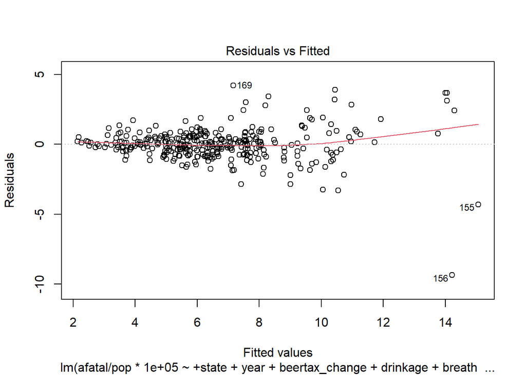

In the quantile-quantile plot of the standardized residuals vs the theoretical normal quantiles, the residuals are clearly not perfectly linear, which challenges the assumption of the normality of the errors, reducing our confidence in the p-values from the regression. We can see that residuals mostly follow a normal distribution in the middle of the graph but curve away from the theoretical quantiles with extreme points. This means that the data set contains more extreme values than expected when compared to a normal distribution.

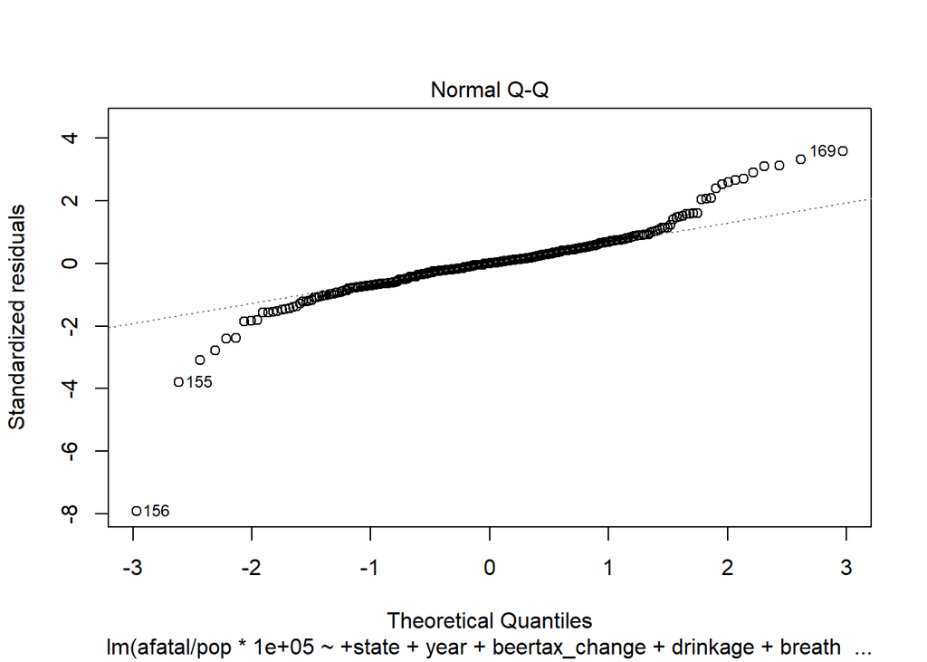

The plot below of Scale-Location shows that the assumption of heterscedasticity is likely not very likely to be valid in this analysis. The red line would be horizontal and the spread would be uniform if the assumption were true (Kim, 2015).

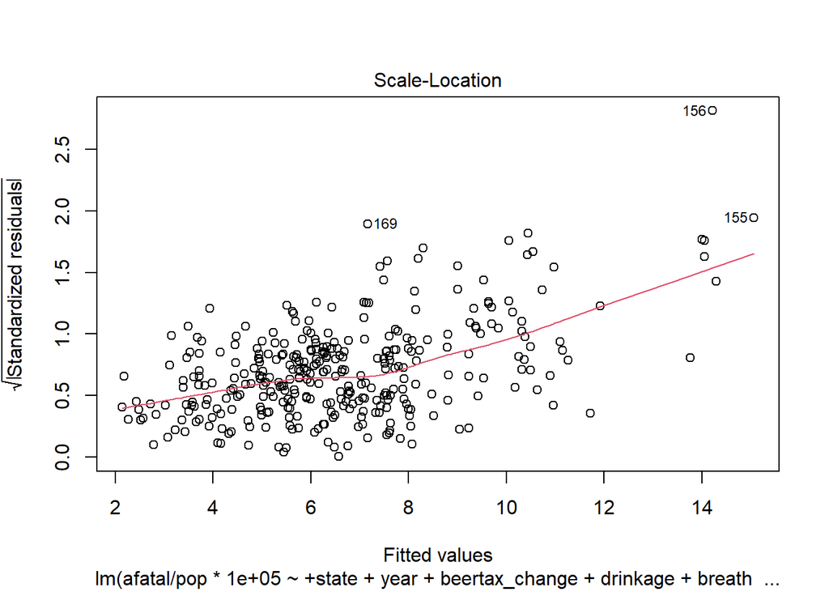

The plot below shows the standardized residuals vs their leverage, with Cook’s distance plotted in dashed red lines. There are not significant outliers, which would be located on the other side of the dashed red lines (Kim, 2015).

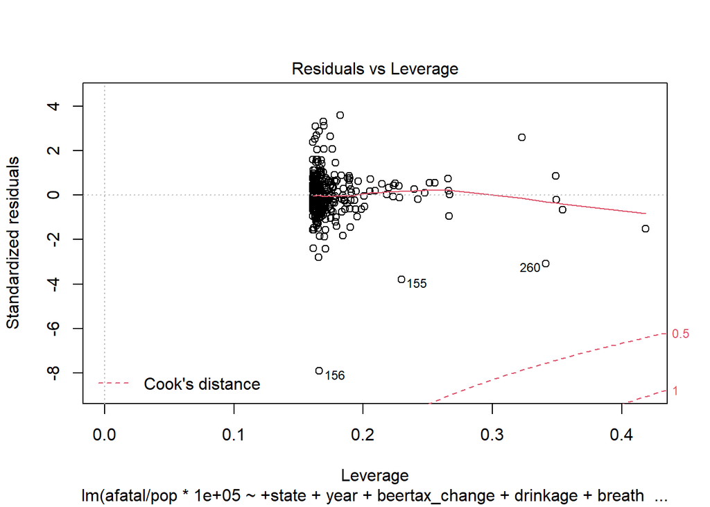

# 8 Discussion and Recommendations

Making suggestions to policy makers with the intent of reducing vehicle traffic fatalities is the central goal of this analysis, but the results presented here likely do not provide sufficient evidence for advocating one policy over another. The fact that many potential explanatory variables are omitted from this analysis is mitigated by the use of the fixed effects approach, which eliminates time-invariant heterogeneity between states, but there are still many missing time-varying variables, the omission of which could bias the results reported here. Additionally, the regression diagnostics results show that the assumptions of ordinary least squares are not strongly supported, including both the normality and homoscedasticity of the errors. Given this, the result that beer tax is significantly involved in reducing alcohol related traffic fatalities is not robust and should be treated with suspicion. Recommendations for making progress in this area include gathering a more comprehensive data set and exploring potential randomized control trials of policies if deemed ethical and where possible, acknowledging the fact that this would be an exceedingly difficult task.

# Acknowledgements

Thank you to Professor Chen for his help during office hours, to the course notes, and to helpful classmates on Piazza.

# References

Blincoe, Lawrence, Ted R. Miller, Eduard Zaloshnja, and Bruce A. Lawrence, The Economic and Societal Impact of Motor Vehicle Crashes, 2010 (Revised), Washington, D.C.: National Highway Traffic Safety Administration, DOT HS 812 013, May 2015. As of July 9, 2015: http://www-nrd.nhtsa.dot.gov/Pubs/812013.pdf

Chen S. STA 207 Lecture Notes. UC Davis. 2021.

Dougherty, C. (2007). Introduction to Econometrics (3rd ed., p. 480). Oxford: Oxford University Press.

Holodny, E. (2016, April 20). Traffic fatalities in the US have been Mostly plummeting for decades. https://www.businessinsider.com/traffic-fatalities-historical-trend-us-2016-4?utm_source=copy-link&utm_medium=referral&utm_content=topbar.

Kim B. Understanding Diagnostic Plots for Linear Regression Analysis. University of Virginia. Research Data Services + Sciences. 2015. https://data.library.virginia.edu/diagnostic-plots/

Sam Schwartz. (2021, January 7). First Look at 2020 Traffic Fatality Rates Shows Sharp Spike. Sam Schwartz : Making the Journey Better. https://www.samschwartz.com/staff-reflections/2020/8/31/first-look-at-2020-traffic-fatality-rates-shows-sharp-spike

Wagenaar, A. C., Salois, M. J., & Komro, K. A. (2009). Effects of beverage alcohol price and tax levels on drinking: a meta-analysis of 1003 estimates from 112 studies. Addiction (Abingdon, England), 104(2), 179–190. https://doi.org/10.1111/j.1360-0443.2008.02438.x

Wagenaar, Alexander C., Melvin D. Livingston, and Stephanie S. Staras. 2015. “Effects of a 2009 Illinois Alcohol Tax Increase on Fatal Motor Vehicle Crashes.” American Journal of Public Health 105 (9): 1880–85.